# ビッグデータ統計解析入門（Chapter 8）

五十嵐未来

2019年4月17日

## Chapter 8『ニューラルネットワークとディープラーニング』

### データセット

使用するデータはMNISTと呼ばれる手書き数字の画像データであり、以下から訓練データとテストデータをダウンロードできます。

訓練データ・テストデータ（zipファイル）

このデータには、0～9のどの数字であるかを示す正解ラベルの`label`と、28×28の各ピクセルについて0～255までの濃度を表す`pixel0`～`pixel783`の変数が含まれています（訓練データ：40,000、テストデータ：2,000）。この画像データをR上で表示するには、以下のようにしてください。

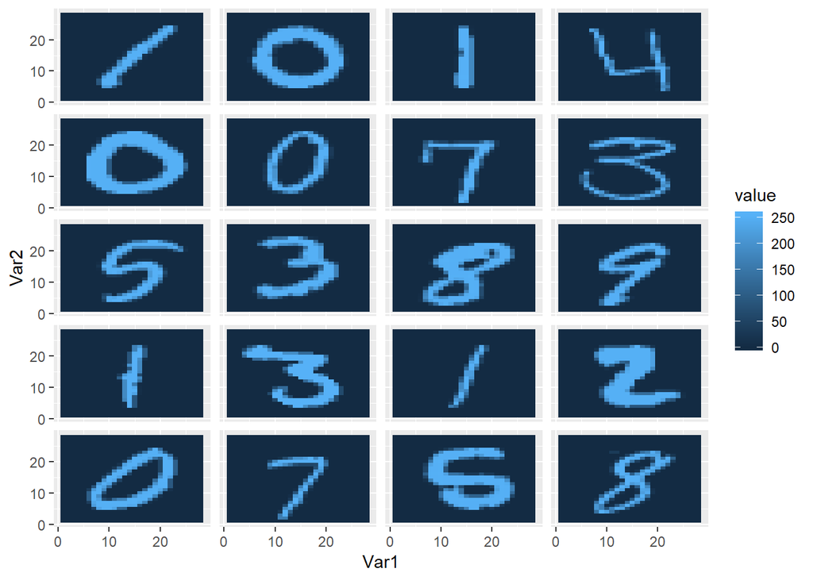

```r
library(data.table)
library(reshape2)
library(ggplot2)

dat = fread("Chap8_train.csv")
arr = array(t(dat[,-1]), dim = c(28, 28, nrow(dat)))

range = 1:20 # range that you want to plot

df = melt(arr[, 28:1, range])
ggplot(df, aes(x = Var1, y = Var2, fill = value)) +
  geom_tile() +
  facet_wrap(~Var3, nrow = 5, ncol = 4) +
  theme(strip.background = element_blank(), strip.text.x = element_blank())
```

この20枚の画像の正解データは以下の通りです。

```
##      [,1] [,2] [,3] [,4]
## [1,]    1    0    1    4
## [2,]    0    0    7    3
## [3,]    5    3    8    9
## [4,]    1    3    1    2
## [5,]    0    7    5    8
```

### 課題

このデータセットを使って以下のタスクを実行してください。

- 訓練データを使ってNeural Network（教科書のRコードではnnet4.Rと同じモデル）及びConvolutional Neural Network（Deep-learning.Rと同じモデル）を学習させよ。
- テストデータを使って手書き数字の予測精度を二つのNeural Networkで比較せよ。また、予測が外れたテストデータのうちいくつかを実際に画像として表示し、なぜ外れたのかを検討せよ。